```python
from IPython.display import display
from IPython.display import HTML

HTML('''<script src="https://cdnjs.cloudflare.com/ajax/libs/jquery/2.0.3/jquery.min.js "></script><script>
code_show=true;
function code_toggle() {
if (code_show){
$('div.jp-CodeCell > div.jp-Cell-inputWrapper').hide();
} else {
$('div.jp-CodeCell > div.jp-Cell-inputWrapper').show();
}
code_show = !code_show
}
$( document ).ready(code_toggle);</script><form action="javascript:code_toggle()"><input type="submit" value="Toggle on/off for raw code"></form>
''')
```

```python
%%HTML
<script src="require.js"></script>
```

# **STEAM ODYSSEY: A Data-Driven Approach to Personalized Gaming**

```python
# IMPORT LIBRARIES
import pandas as pd
import numpy as np
import seaborn as sns
import matplotlib.pyplot as plt

from sklearn.preprocessing import OneHotEncoder
from sklearn.metrics.pairwise import cosine_similarity

import fim
import ast
import csv

# Ignore all warnings
import warnings
warnings.filterwarnings("ignore")

pd.set_option('display.max_columns', None)
```

### **ABSTRACT**

In the rapidly evolving landscape of digital entertainment, the ability to provide tailored game recommendations has become a pivotal asset for enhancing user engagement and satisfaction. This study addresses the challenge of leveraging user preferences and game similarities to offer precise game recommendations. Our research embarked on developing two distinct recommender systems: a unary aggregation-based system and a rules-based system, each designed to analyze and predict game titles that users would likely enjoy, based on their past interactions and preferences.

Our methodology encompassed a comprehensive process starting with meticulous data gathering and preprocessing, which included exploratory data analysis, filtering of reviews for quality, and the elimination of null values to ensure the integrity of our dataset. Subsequently, we focused on constructing detailed user and item profiles through careful feature selection, laying the groundwork for our recommender systems.

Upon building the recommender systems, we proceeded with a rigorous validation phase, employing cosine similarity metrics to benchmark our recommenders against a global baseline and Steam's own recommendation algorithms. Through random sampling, we evaluated the effectiveness and accuracy of our recommendations.

The findings from our study revealed that both the unary aggregation and rules-based recommender systems significantly prioritize game content similarities, diverging from conventional approaches that often rely heavily on popularity or trending metrics. This emphasis on content affinities over mere popularity enables a more personalized recommendation experience, particularly benefiting streamers and content creators who seek to provide unique and tailored content to their audiences. Moreover, our approach democratizes exposure for indie games, offering them equal footing in the recommendation process and thus fostering a richer diversity within the gaming and streaming ecosystem.

In conclusion, our study demonstrates the potential of leveraging sophisticated recommender systems to enhance game discovery and personalization, presenting a valuable tool for streamers, gamers, and the broader gaming community to uncover games that resonate with their individual tastes and preferences.

### **PROBLEM STATEMENT**

In the diverse and ever-expanding universe of digital gaming, both gamers and streamers are constantly faced with an overwhelming choice of titles, making the decision of what game to play next a daunting challenge. This selection process is further complicated by the dynamic nature of gaming trends and the vast array of individual preferences.

Our study is anchored by the critical question: **How can we leverage user preferences and game similarities for effective game recommendations?**

This problem statement underscores the necessity for a nuanced approach to recommendation systems, one that not only navigates through the sheer volume of available games but also aligns closely with the unique tastes and interests of each user. The aim is to transcend traditional recommendation methods, which often prioritize popularity and trends, to develop a system that champions content relevance and personalization, thereby enhancing the gaming experience for users and providing streamers with a toolkit to engage their audience with content that resonates.

### **MOTIVATION**

The genesis of our project is rooted in an understanding of the challenges faced by gamers and streamers in navigating the vast gaming landscape to find titles that resonate both personally and with their audience. This endeavor is not merely about enhancing personal enjoyment but also about fostering a stronger sense of community among viewers and followers.

Additionally, our motivation is significantly influenced by the economic prospects within the game streaming sector. The industry is on a rapid ascent, projected to reach a valuation of over USD 13.65 billion by 2024, with expectations of growth to nearly USD 17.39 billion and 1.6 billion users by 2027. Considering the anticipated average revenue per user to be around USD 10.36 in 2024, the potential for revenue generation in this space is substantial.

Our aim is to develop a recommender system that effectively aligns games with the nuanced preferences of streamers and their audiences. Such a system not only promises to elevate viewer engagement but also opens avenues for increased financial returns for streamers and gaming platforms alike. Through this project, we aspire to refine the process of game discovery, rendering it more efficient and economically beneficial in an industry that continues to expand its reach and impact globally.

### **DATA SOURCE**

For our study, we leveraged two distinct datasets that provide a comprehensive view of the gaming landscape on Steam. These datasets are pivotal for developing our recommender systems, as they offer a deep dive into both the technical aspects and community feedback of thousands of games.

**Steam Games Dataset**

Our primary dataset is a detailed compilation of data on Steam games, obtained from Kaggle. It was meticulously assembled using a custom code (licensed under MIT) that taps into the Steam API and incorporates data from Steam Spy, a reputable third-party service known for its estimates on game sales and user engagement metrics. This dataset encompasses a wide array of information about Steam games, including technical specifications, user engagement metrics, and content descriptions, with a total of 85,103 data points across 39 features.

Source: This dataset was aggregated through a custom-built code that interacts with the Steam API and Steam Spy to fetch a wealth of information on each game. This includes details on estimated ownership, peak concurrent users, pricing, and user reviews. The structured data is then compiled into a CSV file, which has been made available on Kaggle for research purposes.

Collection Process: The custom code queries the Steam API and Steam Spy for comprehensive details on each listed game, capturing essential metrics that offer insights into player engagement and preferences.

Update Frequency: To ensure relevance and accuracy, the dataset undergoes monthly updates. The most recent update, as of this writing, was in January 2024.

**Link to Dataset:** [Steam Games Dataset](https://www.kaggle.com/datasets/fronkongames/steam-games-dataset/data?fbclid=IwAR0vkO-IqWJLDXyhnOcrBb6IESbCyVwe2Sc_g7109q1UPsgfM8olpcxnfkg)

**Table 1.0: Steam Games Dataset Fields**

| Field Name | Data Type | Description |
| --- | --- | --- |
| `AppID` | string | Unique identifier for each app |
| `Name` | string | Game name |
| `Release Date` | string | Release date |
| `Estimated Owners` | string | Estimated owners (e.g., "0 - 20000") |
| `Peak CCU` | int | Number of concurrent users, yesterday |
| `Required age` | int | Age required to play, 0 if for all audiences |
| `Price` | float | Price in USD, 0.0 if it's free |
| `DLC Count` | int | Number of DLCs, 0 if none |
| `About the game` | string | Detailed description of the game |
| `Supported languages` | string | Supported languages (comma-separated) |
| `Full Audio Languages` | string | Languages with audio support (comma-separated) |
| `Reviews` | string | User reviews |
| `Header image` | string | Header image URL in the store |
| `Website` | string | Game website |
| `Support url` | string | Game support URL |
| `Support email` | string | Game support email |
| `Windows` | bool | Does it support Windows? |
| `Mac` | bool | Does it support Mac? |
| `Linux` | bool | Does it support Linux? |
| `Metacritic score` | int | Metacritic score, 0 if none |
| `Metacritic url` | string | Metacritic review URL |
| `User score` | int | Users score, 0 if none |
| `Positive` | int | Positive votes |
| `Negative` | int | Negative votes |
| `Score Rank` | string | Score rank based on user reviews |
| `Achievements` | int | Number of achievements, 0 if none |
| `Recommendations` | int | User recommendations, 0 if none |
| `Notes` | string | Extra information about the game content |
| `Average playtime forever` | int | Average playtime since March 2009, in minutes |
| `Average playtime two weeks` | int | Average playtime in the last two weeks, in minutes |
| `Median playtime forever` | int | Median playtime since March 2009, in minutes |
| `Median playtime two weeks` | int | Median playtime in the last two weeks, in minutes |
| `Developers` | string | Game developers |
| `Publishers` | string | Game publishers |
| `Categories` | string | Game categories |
| `Genres` | string | Game genres |
| `Screenshots` | string | Game screenshots |
| `Movies` | string | Game movies |
| `Tags` | string | Tags |

**Steam Reviews Dataset**

The second dataset in our study encompasses a comprehensive collection of user reviews for video games on the Steam Store. This dataset is rich with details about each review, offering insights beyond mere textual feedback. Key information includes the steam ID, app ID (identifying the reviewed game), playtime (indicating how long the reviewer has played the game), the review text itself, a binary indicator of like/dislike, and timestamps marking when the review was created and last updated. This data was meticulously scraped from the Steam API. It holds rating data from 6M unique users, with 15M reviews over 8,183 games.

By including a diverse set of parameters such as playtime and like/dislike indicators, this dataset offers a multi-dimensional view of user engagement and satisfaction. This dataset is instrumental in our endeavor to develop a recommender system that not only aligns with user preferences based on content similarities but also takes into account the nuanced perspectives of the gaming community.

This detailed compilation of user reviews significantly enriches our research, enabling a deeper understanding of player experiences and preferences. It serves as a critical foundation for tailoring our recommender systems to better match gamers with titles that resonate with their individual tastes and gameplay histories.

**Link to Dataset:** [Steam Reviews Dataset](https://www.kaggle.com/datasets/andrewmvd/steam-reviews?fbclid=IwAR33qWKeMBJIEIOfPsM8AdhtJmq5o1ZnFicuhw1c4aV1aeQYtjIF_fDu9Zc)

**Table 2.0: Steam Reviews Dataset Fields**

| Field Name | Data Type | Description |
| --- | --- | --- |
| steamid | string | The user's ID |
| appid | int | The ID of the game being reviewed |
| voted_up | bool | True means it was a positive recommendation |
| votes_up | int | The number of other users who found this review helpful |
| votes_funny | int | The number of other users who found this review funny |
| weighted_vote_score | float | Helpfulness score |
| playtime_forever | int | How many hours the user had played this game at retrieval |
| playtime_at_review | int | How many hours the user had played the game when writing this review |
| num_games_owned | int | The number of games this user owns |
| num_reviews | int | The number of reviews this user has written |
| review | string | The text of the written review |
| unix_timestamp_created | int | Date the review was created (unix timestamp) |
| unix_timestamp_updated | int | Date the review was last updated (unix timestamp) |

Together, these datasets form the backbone of our research, enabling us to harness machine learning techniques to craft recommender systems that are both insightful and capable of delivering personalized game suggestions based on user preferences and game content similarities.

### **METHODOLOGY**

Below is an explicit overview of the pipeline.

1. **Data Collection and Preparation:**
   - Conducting Exploratory Data Analysis
   - Filtering Reviews
   - Eliminating Null Values
2. **Constructing User and Item Profiles:**
   - Selecting Features for Game Profiles
3. **Developing the Recommender System:**
   - Implementing Unary Aggregation and Rules-Based Approach
   - Fine-Tuning Hyperparameters (Choosing minimum support)
4. **Validation:**
   - Assessing Cosine Similarity against global and Steam baselines, as well as our recommender
   - Employing Random Sampling for Validation

#### **DATE EXPLORATION, CLEANING, AND PREPARATION**

From the initial reviews dataset, we have dropped all reviews that does not have explicit up_votes for the reviewed games. This eliminates any reviews that are neutral in nature or not positively approved by the reviewer. Afterwards, we have consolidated all remaining reviews' associated app_id coming from unique users to essentially build each users' "liked games" list. We then dropped other details that are not needed to build the user profiles.

```python
# Tally user app vote
# user_app_vote_df = pd.read_csv('user_app_vote.csv')
# steamdict = {}

# # Iterate through the DataFrame
# for index, row in user_app_vote_df.iterrows():
#     # Get the steamid and appid
#     steamid = row['steamid']
#     appid = row['appid']
#     voted = row['voted_up']

#     # Check if the steamid is already in the dictionary
#     if steamid not in steamdict:
#         # If not, add it as a key with an empty list as the value
#         steamdict[steamid] = []

#     if voted:
#         steamdict[steamid].append(appid)

# tally = {
#     'steamid': [],
#     'voted_apps': [],
#     'num_apps': []
# }

# for key in steamdict.keys():
#     tally['steamid'].append(key)
#     tally['voted_apps'].append(steamdict[key])
#     tally['num_apps'].append(len(steamdict[key]))

# tally_df = pd.DataFrame(tally)
# tally_df.head()

# tally_df.to_csv('tally_df.csv', index=False)
```

#### **CREATING ITEM AND USER PROFILES**

We're starting by creating item profiles, specifically for games, using a dataset stored in a CSV file.

```python
##########################################
# Creating Item Profiles (Game Profiles) #
##########################################

# Read the CSV file into a pandas DataFrame
games_df = pd.read_csv('games/games.csv')

# Display the first few rows of the DataFrame
print(f'Data Shape: {games_df.shape}')
games_df.head(2)
```

```
Data Shape: (85103, 39)
```

|  | AppID | Name | Release date | Estimated owners | Peak CCU | Required age | Price | DLC count | About the game | Supported languages | Full audio languages | Reviews | Header image | Website | Support url | Support email | Windows | Mac | Linux | Metacritic score | Metacritic url | User score | Positive | Negative | Score rank | Achievements | Recommendations | Notes | Average playtime forever | … |
| --- | --- | --- | --- | --- | --- | --- | --- | --- | --- | --- | --- | --- | --- | --- | --- | --- | --- | --- | --- | --- | --- | --- | --- | --- | --- | --- | --- | --- | --- | --- |
| 0 | 20200 | Galactic Bowling | Oct 21, 2008 | 0 - 20000 | 0 | 0 | 19.99 | 0 | Galactic Bowling is an exaggerated and stylize... | ['English'] | [] | NaN | https://cdn.akamai.steamstatic.com/steam/apps/... | http://www.galacticbowling.net | NaN | NaN | True | False | False | 0 | NaN | 0 | 6 | 11 | NaN | 30 | 0 | NaN | 0 | … |
| 1 | 655370 | Train Bandit | Oct 12, 2017 | 0 - 20000 | 0 | 0 | 0.99 | 0 | THE LAW!! Looks to be a showdown atop a train.... | ['English', 'French', 'Italian', 'German', 'Sp... | [] | NaN | https://cdn.akamai.steamstatic.com/steam/apps/... | http://trainbandit.com | NaN | support@rustymoyher.com | True | True | False | 0 | NaN | 0 | 53 | 5 | NaN | 12 | 0 | NaN | 0 | … |

##### **Item Profiles**

We specifically choose columns that describe the games such as 'AppID', 'Name', 'Developers', 'Publishers', 'Categories', 'Genres', 'Required age', 'Price', 'DLC count', 'Achievements', 'Windows', 'Mac', 'Linux', and 'Estimated owners'. These features are considered relevant for the analysis or modeling task at hand.

```python
###################
# Select Features #
###################

# Selecting features we want to keep for our game profiles
game_features_df = games_df[
    ['AppID', 'Name', 'Developers', 'Publishers',
     'Categories', 'Genres', 'Required age',
     'Price', 'DLC count', 'Achievements',
     'Windows','Mac', 'Linux', 'Estimated owners']]

# Check for null values
print("Null Values:")
cols_with_nulls = game_features_df.columns[game_features_df.isna().sum()>0]
games_df[cols_with_nulls].isna().sum().sort_values(ascending=False)
```

```
Null Values:
```

```
Categories    4598
Publishers    3867
Developers    3587
Genres        3555
Name             6
dtype: int64
```

**Handling Null Values**

We removed any rows with missing values from the DataFrame, ensuring the data's quality and completeness. This approach ensures that only rows containing relevant information are retained, enhancing the dataset's reliability for analysis.

```python
game_features_df.dropna(inplace=True)
game_features_df.head(2)
```

|  | AppID | Name | Developers | Publishers | Categories | Genres | Required age | Price | DLC count | Achievements | Windows | Mac | Linux | Estimated owners |
| --- | --- | --- | --- | --- | --- | --- | --- | --- | --- | --- | --- | --- | --- | --- |
| 0 | 20200 | Galactic Bowling | Perpetual FX Creative | Perpetual FX Creative | Single-player,Multi-player,Steam Achievements,... | Casual,Indie,Sports | 0 | 19.99 | 0 | 30 | True | False | False | 0 - 20000 |
| 1 | 655370 | Train Bandit | Rusty Moyher | Wild Rooster | Single-player,Steam Achievements,Full controll... | Action,Indie | 0 | 0.99 | 0 | 12 | True | True | False | 0 - 20000 |

```python
game_features_df.info()
```

```
<class 'pandas.core.frame.DataFrame'>
Index: 79947 entries, 0 to 85102
Data columns (total 14 columns):
 #   Column            Non-Null Count  Dtype
---  ------            --------------  -----
 0   AppID             79947 non-null  int64
 1   Name              79947 non-null  object
 2   Developers        79947 non-null  object
 3   Publishers        79947 non-null  object
 4   Categories        79947 non-null  object
 5   Genres            79947 non-null  object
 6   Required age      79947 non-null  int64
 7   Price             79947 non-null  float64
 8   DLC count         79947 non-null  int64
 9   Achievements      79947 non-null  int64
 10  Windows           79947 non-null  bool
 11  Mac               79947 non-null  bool
 12  Linux             79947 non-null  bool
 13  Estimated owners  79947 non-null  object
dtypes: bool(3), float64(1), int64(4), object(6)
memory usage: 7.5+ MB
```

We're now addressing special cases by encoding the 'Categories' and 'Genres' columns, as they are stored as strings but represent multiple values. To handle this, we convert these columns into strings, then split the strings by comma and create dummy variables for each category and genre.

```python
#########################
# Encoded Special Cases #
#########################

# Encode Categories and Genres (Special Cases since they are stored as string)
# Convert lists to strings and separate elements by comma
game_features_df['Categories'] = game_features_df['Categories'].astype(str)
game_features_df['Genres'] = game_features_df['Genres'].astype(str)

# Split the strings by comma and create dummy variables
categories_dummy = game_features_df['Categories'].str.get_dummies(',')
genres_dummy = game_features_df['Genres'].str.get_dummies(',')

# Prefix columns appropriately
categories_dummy = categories_dummy.add_prefix('Categories_')
genres_dummy = genres_dummy.add_prefix('Genres_')

# Concatenate all the dummy variables
separated_df = pd.concat([categories_dummy, genres_dummy], axis=1)

# Concatenate the separated dummy variables with the original DataFrame
game_features_encoded = pd.concat([game_features_df, separated_df], axis=1)
game_features_encoded.head()
```

|  | AppID | Name | Developers | Publishers | Categories | Genres | Required age | Price | DLC count | Achievements | ... | Genres_Short | Genres_Simulation | Genres_Software Training | Genres_Sports | Genres_Strategy | Genres_Tutorial | Genres_Utilities | Genres_Video Production | Genres_Violent | Genres_Web Publishing |
| --- | --- | --- | --- | --- | --- | --- | --- | --- | --- | --- | --- | --- | --- | --- | --- | --- | --- | --- | --- | --- | --- |
| 0 | 20200 | Galactic Bowling | Perpetual FX Creative | Perpetual FX Creative | Single-player,Multi-player,Steam Achievements,... | Casual,Indie,Sports | 0 | 19.99 | 0 | 30 | ... | 0 | 0 | 0 | 1 | 0 | 0 | 0 | 0 | 0 | 0 |
| 1 | 655370 | Train Bandit | Rusty Moyher | Wild Rooster | Single-player,Steam Achievements,Full controll... | Action,Indie | 0 | 0.99 | 0 | 12 | ... | 0 | 0 | 0 | 0 | 0 | 0 | 0 | 0 | 0 | 0 |
| 2 | 1732930 | Jolt Project | Campião Games | Campião Games | Single-player | Action,Adventure,Indie,Strategy | 0 | 4.99 | 0 | 0 | ... | 0 | 0 | 0 | 0 | 1 | 0 | 0 | 0 | 0 | 0 |
| 3 | 1355720 | Henosis™ | Odd Critter Games | Odd Critter Games | Single-player,Full controller support | Adventure,Casual,Indie | 0 | 5.99 | 0 | 0 | ... | 0 | 0 | 0 | 0 | 0 | 0 | 0 | 0 | 0 | 0 |
| 4 | 1139950 | Two Weeks in Painland | Unusual Games | Unusual Games | Single-player,Steam Achievements | Adventure,Indie | 0 | 0.00 | 0 | 17 | ... | 0 | 0 | 0 | 0 | 0 | 0 | 0 | 0 | 0 | 0 |

5 rows × 88 columns

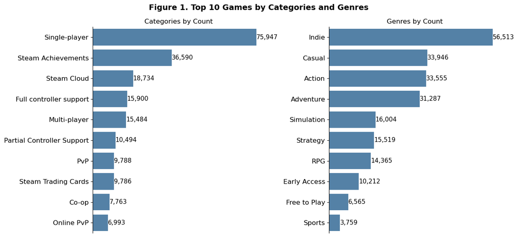

```python
cat_dummy = game_features_df['Categories'].str.get_dummies(',')
gen_dummy = game_features_df['Genres'].str.get_dummies(',')

cat = cat_dummy.sum().sort_values(ascending=False).head(10)
genre = gen_dummy.sum().sort_values(ascending=False).head(10)

fig, axes = plt.subplots(1,2, figsize=(13,6))

sns.barplot(x=cat.values, y=cat.index, color='steelblue', orient='h', ax=axes[0])
for index, value in enumerate(cat):
    axes[0].text(value, index, f'{value:,.0f}', ha='left', va='center', color='black', fontsize=11)

sns.barplot(x=genre.values, y=genre.index, color='steelblue', orient='h', ax=axes[1])
for index, value in enumerate(genre):
    axes[1].text(value, index, f'{value:,.0f}', ha='left', va='center', color='black', fontsize=11)

for ax in axes:
    for label in ax.yaxis.get_ticklabels():
        # label.set_fontweight('bold')
        label.set_color('black')
        label.set_fontsize('12')

axes[0].set_title("Categories by Count", color='black', fontsize=12)
axes[0].set_xticks([])

axes[1].set_title("Genres by Count", color='black', fontsize=12)
axes[1].set_xticks([])

plt.suptitle('Figure 1. Top 10 Games by Categories and Genres', fontsize=14, fontweight='bold')
plt.tight_layout()
sns.despine(top=True, right=True, bottom=True)
plt.show()
```

It is important to note that these games can be tagged under multiple categories and genres. For instance, among the top five categories (Single-player, Steam Achievements, Steam Cloud, Full controller support, and Multi-player), games like 'Forza Horizon 4', 'Good Knight', and 'Superola Champion Edition' have these category tags. Similarly, within the top five genres (Indie, Casual, Action, Adventure, and Simulation), titles such as 'Girlfriend Cards', 'RoadPunk', and 'Blame Him' exhibit these genre tags.

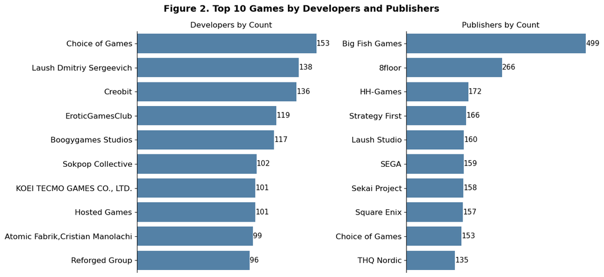

```python
dev = game_features_df.groupby('Developers')['Name'].nunique().sort_values(ascending=False).head(10)
pub = game_features_df.groupby('Publishers')['Name'].nunique().sort_values(ascending=False).head(10)

fig, axes = plt.subplots(1,2, figsize=(13,6))

sns.barplot(x=dev.values, y=dev.index, color='steelblue', orient='h', ax=axes[0])
for index, value in enumerate(dev):
    axes[0].text(value, index, f'{value:,.0f}', ha='left', va='center', color='black', fontsize=11)

sns.barplot(x=pub.values, y=pub.index, color='steelblue', orient='h', ax=axes[1])
for index, value in enumerate(pub):
    axes[1].text(value, index, f'{value:,.0f}', ha='left', va='center', color='black', fontsize=11)

for ax in axes:
    for label in ax.yaxis.get_ticklabels():
        # label.set_fontweight('bold')
        label.set_color('black')
        label.set_fontsize('12')

axes[0].set_title("Developers by Count", color='black', fontsize=12)
axes[0].set_xticks([])
axes[0].set_ylabel('')

axes[1].set_title("Publishers by Count", color='black', fontsize=12)
axes[1].set_xticks([])
axes[1].set_ylabel('')

plt.suptitle('Figure 2. Top 10 Games by Developers and Publishers', fontsize=14, fontweight='bold')
plt.tight_layout()
sns.despine(top=True, right=True, bottom=True)
plt.show()
```

The developer 'Choice of Games' stands out as the top developer with the largest number of games in the dataset. Notable works by 'Choice of Games' include 'Choice of the Star Captain', "Thieves' Gambit: The Curse of the Black Cat", and 'The Superlatives: Shattered Worlds'.

On the other hand, the publisher 'Big Fish Games' emerges as the leading publisher with the highest number of games in the dataset. Among its published titles are "Grim Tales: The Heir Collector's Edition", "Surface: Return to Another World Collector's Edition", and 'Mystery Case Files: Ravenhearst'.

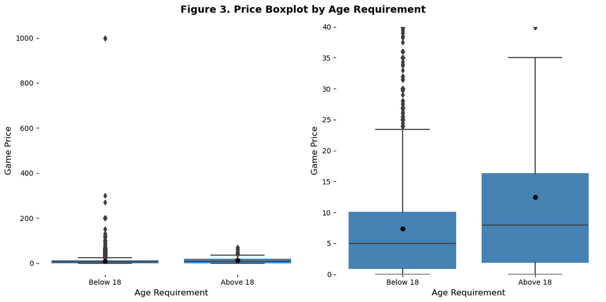

```python
game_features_df['Age Requirement'] = np.where(game_features_df['Required age']>=18, 'Above 18', 'Below 18')

fig, axes = plt.subplots(1, 2, figsize=(12, 6))

# Chart 1
sns.boxplot(x=game_features_df['Age Requirement'], y=game_features_df['Price'], showmeans=True,
            meanprops={'marker':'o', 'markerfacecolor':'black', 'markeredgecolor':'black'},
            boxprops=dict(color='steelblue'), whiskerprops=dict(), capprops=dict(), ax=axes[0])


# Chart 2 - with ylim
sns.boxplot(x=game_features_df['Age Requirement'], y=game_features_df['Price'], showmeans=True,
            meanprops={'marker':'o', 'markerfacecolor':'black', 'markeredgecolor':'black'},
            boxprops=dict(color='steelblue'), whiskerprops=dict(), capprops=dict(), ax=axes[1])
axes[1].set_ylim(0, 40)

for ax in axes:
    ax.set_xlabel('Age Requirement', color='black', fontsize=12)
    ax.set_ylabel('Game Price', color='black', fontsize=12)
    sns.despine(ax=ax, top=True, bottom=True, right=True, left=True)

plt.suptitle('Figure 3. Price Boxplot by Age Requirement', fontsize=14, fontweight='bold')
plt.tight_layout()
plt.show()
```

When examining game prices and age requirements, a notable trend emerges: games that require players to be above 18 years old generally command higher prices. This could be attributed to the higher disposable income of adult gamers. However, intriguingly, there are games targeting players below 18 years old that are priced significantly higher, surpassing even some adult-oriented games with prices reaching up to 1000 USD. Examples of such games include 'Ascent Free-Roaming VR Experience', 'The Leverage Game', and 'The Leverage Game Business Edition'.

**Games with the most number of estimated owners**

```python
high_owners_games = game_features_df[game_features_df['Estimated owners'].isin(['50000000 - 100000000', '100000000 - 200000000'])]
high_owners_games[['Name', 'Estimated owners']].sort_values('Estimated owners').reset_index(drop=True)
```

|  | Name | Estimated owners |
| --- | --- | --- |
| 0 | Dota 2 | 100000000 - 200000000 |
| 1 | New World | 50000000 - 100000000 |
| 2 | PUBG: BATTLEGROUNDS | 50000000 - 100000000 |
| 3 | Team Fortress 2 | 50000000 - 100000000 |
| 4 | Counter-Strike: Global Offensive | 50000000 - 100000000 |

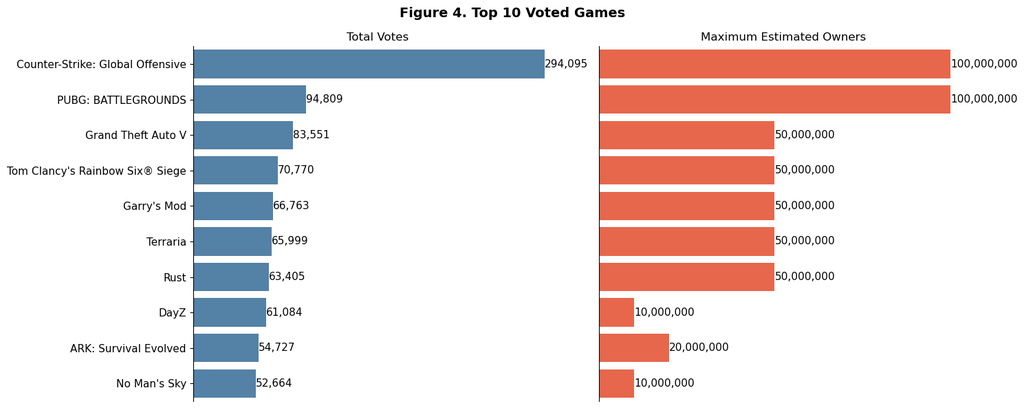

```python
user_app_vote_df = pd.read_csv('user_app_vote.csv')

vote_up = user_app_vote_df[user_app_vote_df['voted_up']==True]
agg_vote = user_app_vote_df.groupby('appid')['steamid'].nunique().sort_values(ascending=False).reset_index().rename(columns={'steamid':'Total Votes'})
game_feature_with_votes = game_features_df.merge(agg_vote, how='left', left_on='AppID', right_on='appid')[['AppID', 'Name', 'Estimated owners', 'Total Votes']]

df = game_feature_with_votes.sort_values('Total Votes', ascending=False).head(10)

fig, axes = plt.subplots(1, 2, figsize=(15, 6))

# Plotting Total Votes
sns.barplot(x=df['Total Votes'], y=df['Name'], ax=axes[0], color='steelblue')

for index, value in enumerate(df['Total Votes']):
    axes[0].text(value, index, f'{value:,.0f}', ha='left', va='center', color='black', fontsize=11)

# Mapping Estimated Owners to numerical values using maximum number of each range
owners_mapping = {'50000000 - 100000000': 100000000, '20000000 - 50000000': 50000000,
                  '5000000 - 10000000': 10000000, '10000000 - 20000000': 20000000}
df['Owners Value'] = df['Estimated owners'].map(owners_mapping)

# Plotting Estimated owners
sns.barplot(x=df['Owners Value'], y=df['Name'], ax=axes[1], color='#FF5733')
for index, value in enumerate(df['Owners Value']):
    axes[1].text(value, index, f'{value:,.0f}', ha='left', va='center', color='black', fontsize=11)

# Formatting plot aesthetics
for ax in axes:
    ax.set_ylabel('')
    ax.spines['right'].set_visible(False)
    ax.spines['top'].set_visible(False)
    ax.spines['bottom'].set_visible(False)
    ax.set_xticks([])
    for label in ax.yaxis.get_ticklabels():
        label.set_fontsize('11')

axes[0].set_title("Total Votes", fontsize=12)
axes[1].set_title("Maximum Estimated Owners", fontsize=12)
axes[0].set_xlabel('')
axes[1].set_xlabel('')
axes[1].set_yticks([])

plt.suptitle('Figure 4. Top 10 Voted Games', fontsize=14, fontweight='bold')
plt.tight_layout()
plt.show()
```

The top-voted games are determined by the number of "vote_up" instances from users. Counter-Strike: Global Offensive claims the top spot in the item profile due to its substantial number of owners. However, other games boasting a significant owner base, such as Dota 2, New World, and Team Fortress 2, did not secure top-voted positions despite their large user bases. This observation suggests that the majority of players engaged with these games may not actively contribute reviews, thus influencing their ranking in the top-voted games list.

### **Item Profile**

Moving on to one-hot encoding, we select relevant columns including 'Developers', 'Publishers', and 'Estimated owners'. Utilizing the OneHotEncoder from scikit-learn, we transform each categorical column separately, obtaining one-hot encoded representations. We're extending our one-hot encoding process to include infrequent categories by initializing the OneHotEncoder with the 'min_frequency' parameter set to 0.001. This ensures that categories with a frequency below this threshold are also encoded.

Following this, we encode boolean columns ('Windows', 'Mac', 'Linux') as float values and create derived columns based on numeric values ('Required age', 'Price', 'DLC count', 'Achievements') to represent binary attributes ('Age 18+', 'IsPaid', 'Has DLC', 'Has Achievement').

```python
##################
# One Hot Encode #
##################

# Assuming game_features_encoded is your DataFrame containing game features with separated dummy variables
developers_publishers_df = game_features_encoded[['Developers', 'Publishers', 'Estimated owners']]

# Initialize OneHotEncoder
encoder = OneHotEncoder(min_frequency=0.001)

# Fit and transform 'Developers' column
developers_encoded = encoder.fit_transform(developers_publishers_df[['Developers']])
developers_columns = encoder.get_feature_names_out(['Developers'])

# Fit and transform 'Publishers' column
publishers_encoded = encoder.fit_transform(developers_publishers_df[['Publishers']])
publishers_columns = encoder.get_feature_names_out(['Publishers'])

# Fit and transform 'Estimated owners' column
owners_encoded = encoder.fit_transform(developers_publishers_df[['Estimated owners']])
owners_columns = encoder.get_feature_names_out(['Estimated owners'])

# Concatenate the one-hot encoded columns with the original DataFrame
game_features_encoded_final = pd.concat([
    game_features_encoded,
    pd.DataFrame(developers_encoded.toarray(), columns=developers_columns),
    pd.DataFrame(publishers_encoded.toarray(), columns=publishers_columns),
    pd.DataFrame(owners_encoded.toarray(), columns=owners_columns)], axis=1)


##################
# Encode Boolean #
##################
game_features_encoded_final['Windows'] = game_features_encoded_final['Windows'].fillna(False).astype(float)
game_features_encoded_final['Mac'] = game_features_encoded_final['Mac'].fillna(False).astype(float)
game_features_encoded_final['Linux'] = game_features_encoded_final['Linux'].fillna(False).astype(float)


########################################
# Derived Columns from Numeric Values #
########################################
game_features_encoded_final['Age 18+'] = (
    game_features_encoded_final['Required age'] >= 18).astype(float)
game_features_encoded_final['IsPaid'] = (
    game_features_encoded_final['Price'] > 0).astype(float)
game_features_encoded_final['Has DLC'] = (
    game_features_encoded_final['DLC count'] > 0).astype(float)
game_features_encoded_final['Has Achievement'] = (
    game_features_encoded_final['Achievements'] > 0).astype(float)


###########
# Cleanup #
###########

# Drop the original columns
game_features_encoded_final.drop(columns=[
    'Developers',
    'Publishers',
    'Genres',
    'Categories',
    'Estimated owners',
    'Required age',
    'Price',
    'DLC count',
    'Achievements'], inplace=True)

# Fix AppID
game_features_encoded_final['AppID'] = (game_features_encoded_final['AppID']
                                        .astype(str))
game_features_encoded_final['AppID'] = (game_features_encoded_final['AppID']
                                        .str.replace('\.0$', '', regex=True))
game_features_encoded_final.rename(columns={'AppID': 'appid'}, inplace=True)
game_features_encoded_final.head()
```

|  | appid | Name | Windows | Mac | Linux | Categories_Captions available | Categories_Co-op | Categories_Commentary available | Categories_Cross-Platform Multiplayer | Categories_Full controller support | ... | Estimated owners_200000 - 500000 | Estimated owners_2000000 - 5000000 | Estimated owners_50000 - 100000 | Estimated owners_500000 - 1000000 | Estimated owners_5000000 - 10000000 | Estimated owners_infrequent_sklearn | Age 18+ | IsPaid | Has DLC | Has Achievement |
| --- | --- | --- | --- | --- | --- | --- | --- | --- | --- | --- | --- | --- | --- | --- | --- | --- | --- | --- | --- | --- | --- |
| 0 | 20200 | Galactic Bowling | 1.0 | 0.0 | 0.0 | 0.0 | 0.0 | 0.0 | 0.0 | 0.0 | ... | 0.0 | 0.0 | 0.0 | 0.0 | 0.0 | 0.0 | 0.0 | 1.0 | 0.0 | 1.0 |
| 1 | 655370 | Train Bandit | 1.0 | 1.0 | 0.0 | 0.0 | 0.0 | 0.0 | 0.0 | 1.0 | ... | 0.0 | 0.0 | 0.0 | 0.0 | 0.0 | 0.0 | 0.0 | 1.0 | 0.0 | 1.0 |
| 2 | 1732930 | Jolt Project | 1.0 | 0.0 | 0.0 | 0.0 | 0.0 | 0.0 | 0.0 | 0.0 | ... | 0.0 | 0.0 | 0.0 | 0.0 | 0.0 | 0.0 | 0.0 | 1.0 | 0.0 | 0.0 |
| 3 | 1355720 | Henosis™ | 1.0 | 1.0 | 1.0 | 0.0 | 0.0 | 0.0 | 0.0 | 1.0 | ... | 0.0 | 0.0 | 0.0 | 0.0 | 0.0 | 0.0 | 0.0 | 1.0 | 0.0 | 0.0 |
| 4 | 1139950 | Two Weeks in Painland | 1.0 | 1.0 | 0.0 | 0.0 | 0.0 | 0.0 | 0.0 | 0.0 | ... | 0.0 | 0.0 | 0.0 | 0.0 | 0.0 | 0.0 | 0.0 | 0.0 | 0.0 | 1.0 |

5 rows × 146 columns

```python
########################
# Output Item Profiles #
########################

# output_file_path = "item_profiles.csv"

# # Output the DataFrame to a CSV file
# game_features_encoded_final.to_csv(output_file_path, index=False)
```

##### **User Profiles**

We're now venturing into creating user profiles based on their app votes. Initially, we read a CSV file containing user app vote data.

```python
##########################
# Creating User Profiles #
##########################

# Filter to only users that have rated at least 10 apps
tally_df = pd.read_csv('tally_df.csv')
tally_df.head()

filtered_tally_df = tally_df[tally_df['num_apps'] >= 10]

# Encode user profile based on the tallied votes
all_apps = []
for row in tally_df['voted_apps']:
    voted_apps_arr = ast.literal_eval(row)
    all_apps.extend(voted_apps_arr)

all_apps_final = sorted(list(set(all_apps)))
columns_count = len(all_apps_final)
```

To create the user profile -- For each user, we construct a row of zeros representing whether each app has been voted for. We iterate through the voted apps for each user, and set the corresponding elements in the row to 1. We then write this row to the CSV file along with the user's steam ID.

```python
# Write rows to file
# with open('user_profiles.csv', mode='w', newline='') as file:
#     writer = csv.writer(file)

#     # Write header row
#     header_row = ['steamid'] + all_apps_final
#     writer.writerow(header_row)

#     # Populate rows with data
#     for i in range(len(filtered_tally_df)):
#         row = np.zeros((1, columns_count))
#         voted_apps = sorted(ast.literal_eval(filtered_tally_df.iloc[i]['voted_apps']))
#         indices = [all_apps_final.index(app) for app in voted_apps]
#         for ix in indices:
#             row[0][ix] = 1
#         writer.writerow([filtered_tally_df.iloc[i][0]] + row[0].tolist())
```

#### **IMPLEMENTATION AND RESULTS**

##### **Building the Recommenders**

Now that we have our user and item profiles, we can proceed with building our recommenders.

```python
###########################
# Building Recommenders #
###########################

# Item Profiles
item_profiles_df = pd.read_csv('item_profiles.csv')
item_profiles_df = item_profiles_df.dropna(subset=['appid'])
item_profiles_df['appid'] = item_profiles_df['appid'].astype(int)
item_profiles_df.set_index('appid', inplace=True)

# User Profiles
user_profiles_df = pd.read_csv('user_profiles.csv')
user_profiles_df.set_index('steamid', inplace=True)
```

We apply a cleanup step to replace all 0 values in the user profiles DataFrame with NaN, signifying that these items are 'unrated'.

```python
# Cleanup User Profiles
clean_user_profiles_df = user_profiles_df.copy()
clean_user_profiles_df = (clean_user_profiles_df
                          .loc[:, (clean_user_profiles_df != 0)
                               .any(axis=0)])
# Fix column types
column_mapping = {col: int(col)
                  for col in clean_user_profiles_df.columns}
clean_user_profiles_df.rename(columns=column_mapping, inplace=True)

# Replace 0 with NaN
clean_user_profiles_df.replace(0, np.nan, inplace=True)
clean_user_profiles_df.head()
```

| steamid | 10 | 20 | 30 | 40 | 50 | 60 | 70 | 80 | 130 | 220 | ... | 1020470 | 1020820 | 1023980 | 1025050 | 1029630 | 1031480 | 1032430 | 1035610 | 1046030 | 1051310 |
| --- | --- | --- | --- | --- | --- | --- | --- | --- | --- | --- | --- | --- | --- | --- | --- | --- | --- | --- | --- | --- | --- |
| 76561198254602420 | 1.0 | NaN | NaN | NaN | NaN | NaN | NaN | NaN | NaN | NaN | ... | NaN | NaN | NaN | NaN | NaN | NaN | NaN | NaN | NaN | NaN |
| 76561198082706574 | 1.0 | NaN | NaN | NaN | NaN | NaN | NaN | NaN | NaN | NaN | ... | NaN | NaN | NaN | NaN | NaN | NaN | NaN | NaN | NaN | NaN |
| 76561198169738151 | 1.0 | NaN | NaN | NaN | NaN | NaN | NaN | NaN | NaN | NaN | ... | NaN | NaN | NaN | NaN | NaN | NaN | NaN | NaN | NaN | NaN |
| 76561198084258429 | 1.0 | NaN | NaN | NaN | NaN | NaN | NaN | NaN | NaN | 1.0 | ... | NaN | NaN | NaN | NaN | NaN | NaN | NaN | NaN | NaN | NaN |
| 76561198147283227 | 1.0 | NaN | NaN | NaN | 1.0 | NaN | NaN | NaN | 1.0 | 1.0 | ... | NaN | NaN | NaN | NaN | NaN | NaN | NaN | NaN | NaN | NaN |

5 rows × 7630 columns

```python
# Cleanup Item Profiles
clean_item_profiles_df = item_profiles_df.copy()
clean_item_profiles_df.drop(columns='Name', inplace=True)

clean_item_profiles_df.head()
```

| appid | Windows | Mac | Linux | Categories_Captions available | Categories_Co-op | Categories_Commentary available | Categories_Cross-Platform Multiplayer | Categories_Full controller support | Categories_HDR available | Categories_In-App Purchases | ... | Estimated owners_200000 - 500000 | Estimated owners_2000000 - 5000000 | Estimated owners_50000 - 100000 | Estimated owners_500000 - 1000000 | Estimated owners_5000000 - 10000000 | Estimated owners_infrequent_sklearn | Age 18+ | IsPaid | Has DLC | Has Achievement |
| --- | --- | --- | --- | --- | --- | --- | --- | --- | --- | --- | --- | --- | --- | --- | --- | --- | --- | --- | --- | --- | --- |
| 20200 | 1.0 | 0.0 | 0.0 | 0.0 | 0.0 | 0.0 | 0.0 | 0.0 | 0.0 | 0.0 | ... | 0.0 | 0.0 | 0.0 | 0.0 | 0.0 | 0.0 | 0.0 | 1.0 | 0.0 | 1.0 |
| 655370 | 1.0 | 1.0 | 0.0 | 0.0 | 0.0 | 0.0 | 0.0 | 1.0 | 0.0 | 0.0 | ... | 0.0 | 0.0 | 0.0 | 0.0 | 0.0 | 0.0 | 0.0 | 1.0 | 0.0 | 1.0 |
| 1732930 | 1.0 | 0.0 | 0.0 | 0.0 | 0.0 | 0.0 | 0.0 | 0.0 | 0.0 | 0.0 | ... | 0.0 | 0.0 | 0.0 | 0.0 | 0.0 | 0.0 | 0.0 | 1.0 | 0.0 | 0.0 |
| 1355720 | 1.0 | 1.0 | 1.0 | 0.0 | 0.0 | 0.0 | 0.0 | 1.0 | 0.0 | 0.0 | ... | 0.0 | 0.0 | 0.0 | 0.0 | 0.0 | 0.0 | 0.0 | 1.0 | 0.0 | 0.0 |
| 1139950 | 1.0 | 1.0 | 0.0 | 0.0 | 0.0 | 0.0 | 0.0 | 0.0 | 0.0 | 0.0 | ... | 0.0 | 0.0 | 0.0 | 0.0 | 0.0 | 0.0 | 0.0 | 0.0 | 0.0 | 1.0 |

5 rows × 144 columns

We also filter out only common items in our user and item profiles.

```python
# Filter out only common columns
common_app_columns = clean_user_profiles_df.columns.intersection(
    clean_item_profiles_df.index)
clean_user_profiles_df = clean_user_profiles_df[common_app_columns]
clean_item_profiles_df = (clean_item_profiles_df
                          [clean_item_profiles_df.index.isin
                           (clean_user_profiles_df.columns.tolist())])
```

```python
print("User Profiles Shape:")
clean_user_profiles_df.shape
```

```
User Profiles Shape:
```

```
(26949, 7411)
```

```python
print("Item Profiles Shape:")
clean_item_profiles_df.shape
```

```
Item Profiles Shape:
```

```
(7411, 144)
```

We then establish an initial user liked games for comparison to establish baselines of the recommender system.

We first define a sample user ID, 'sample_user' as user `76561198254602420`, and the number of recommendations desired, 'n_recommendations' as `5`. Then retrieve the user's liked games. These will be used for initial comparison and baseline establishment of the recommender system.

```python
############################
# Initial User Liked Games #
############################
sample_user = 76561198254602420
n_recommendations = 5

user_liked = clean_user_profiles_df.loc[sample_user].dropna().index
item_profiles_df['Name'][user_liked]
```

```
10                                 Counter-Strike
240                        Counter-Strike: Source
10090                  Call of Duty: World at War
10180     Call of Duty®: Modern Warfare® 2 (2009)
64000                   Men of War: Assault Squad
203770                          Crusader Kings II
214950      Total War™: ROME II - Emperor Edition
242760                                 The Forest
325610                          Total War: ATTILA
359550            Tom Clancy's Rainbow Six® Siege
394360                          Hearts of Iron IV
460930        Tom Clancy's Ghost Recon® Wildlands
Name: Name, dtype: object
```

From here, we will be implemention unary aggregation methods and rules-based methods for computing user profiles and making recommendations.

**Unary Aggregation**

```python
#############
# Unary Agg #
#############

def calculate_cosine_similarity(rated_profiles, recommended_profiles):
    similarity_matrix = cosine_similarity(rated_profiles.values, recommended_profiles.values)
    mean_similarity_score = similarity_matrix.mean()
    return mean_similarity_score


def compute_user_profile_agg_unary(df_utility, df_item_profiles, user):
    """Compute the user profile by unary aggregation."""
    user_ratings = df_utility.loc[user]
    mean = user_ratings.mean()
    user_ratings = user_ratings.apply(lambda x: 1 if x >= mean else 0)

    nan_mask = np.isnan(user_ratings)
    weighted_profiles = (user_ratings.values.reshape(-1, 1)
                         * df_item_profiles.values)

    weighted_profiles[nan_mask] = 0
    user_profiles = (weighted_profiles.sum(axis=0)
                     / user_ratings.mask(nan_mask).sum())

    return user_profiles


def recommend_agg_unary(df_utility, df_item_profiles, user_profile, user, L):
    """Recommend L items to the user based on unary aggregation method."""
    similarities = cosine_similarity([user_profile], df_item_profiles)
    sorted_indices = np.argsort(similarities[0])[::-1]

    recommended_items = []
    seen_items = set(df_utility.loc[user].dropna().index)
    for idx in sorted_indices:
        item_id = df_item_profiles.iloc[idx].name
        if item_id not in seen_items:
            recommended_items.append(item_id)
            if len(recommended_items) == L:
                break

    return recommended_items
```

```python
user_profile_agg_unary = compute_user_profile_agg_unary(
    clean_user_profiles_df, clean_item_profiles_df, sample_user
)
recommended_unary = recommend_agg_unary(clean_user_profiles_df,
                                  clean_item_profiles_df,
                                  user_profile_agg_unary,
                                  sample_user,
                                  n_recommendations)

print("Recommended Games Based on Unary Aggregation:")
recommended_unary
```

```
Recommended Games Based on Unary Aggregation:
```

```
[518730, 22200, 665270, 551550, 251410]
```

```python
item_profiles_df['Name'][recommended_unary]
```

```
appid
518730                                  Zombo Buster Rising
22200                                            Zeno Clash
665270    弹幕音乐绘 ～风雷幻奏曲～ / Barrage Musical  ~A Fantasy of...
551550                                    ASSASSINATION BOX
251410                                          Dark Matter
Name: Name, dtype: object
```

```python
recommended_profiles = clean_item_profiles_df.loc[recommended_unary][:n_recommendations]
rated_profiles = clean_item_profiles_df.loc[user_liked][:n_recommendations]

similarity_score = calculate_cosine_similarity(rated_profiles, recommended_profiles)
print("Similarity score (Cosine):", similarity_score)
```

```
Similarity score (Cosine): 0.607727707302457
```

The similarity score for recommended profiles obtained through unary association rules, with a specified number of recommendations. This yields a cosine similarity score of approximately 0.608.

**Rules Based**

```python
###############
# Rules Based #
###############

def find_rules_unary(df_utility, df_item_profiles, user, minsup, minconf):
    """Compute the user profile using rules."""
    rated_items = df_utility.loc[user].dropna().index.tolist()

    transactions = pd.Series(index=rated_items, dtype=object)
    for item in rated_items:
        t_features = (df_item_profiles.loc[item]
                      [df_item_profiles.loc[item] > 0]
                      .index.tolist())
        transactions[item] = t_features

    patterns = fim.fpgrowth(transactions.values, supp=minsup)

    rules = []
    for pattern, support in patterns:
        features = sorted(list(set(pattern)))
        indices = [item for item, item_features in transactions.items()
                   if set(features).issubset(item_features)]
        ratings = ['LIKE' if rating > 0 else None for rating
                   in df_utility.loc[user][indices]]
        ratings_dict = {}
        for item in ratings:
            if item in ratings_dict:
                ratings_dict[item] += 1
            else:
                ratings_dict[item] = 1
        rating = max(ratings_dict, key=lambda x: ratings_dict[x])
        confidence = (ratings_dict[rating] / len(indices)) * 100
        if features and rating and confidence >= minconf:
            new_rule = {
                'rating': rating,
                'features': features,
                'confidence': confidence}
            rules.append(new_rule)

    rules.sort(key=lambda x: (-x['confidence'], x['features']))

    return rules


def recommend_rules(df_utility, df_item_profiles, user_profile, user, L):
    """Recommend L items to the user based on the rules method."""
    item_scores = {}
    rated_items = set(df_utility.loc[user].dropna().index)
    for item_id, item_profile in df_item_profiles.iterrows():
        if item_id in rated_items:
            continue

        score = 0
        features = (df_item_profiles.loc[item_id]
                    [df_item_profiles.loc[item_id] > 0]
                    .index.tolist())

        for rule in user_profile:
            if set(rule['features']).issubset(features):
                if rule['rating'] == 'LIKE':
                    score += (rule['confidence'])
                elif rule['rating'] == 'DISLIKE':
                    score -= (rule['confidence'])
        item_scores[item_id] = score

    sorted_items = sorted(item_scores.items(), key=lambda x: (-x[1], x[0]))
    recommended_items = [item[0] for item in sorted_items[:L]]

    return recommended_items
```

**Hyperparameter Tuning**

We aim to evaluate the similarity score between a user's liked items and recommended items using association rule mining techniques. To achieve this, we define a function calculate_similarity_score that orchestrates the process by extracting user preferences, generating association rules, recommending items, and computing similarity scores based on cosine similarity. These steps are executed iteratively for varying minimum support values, producing a set of results including the minimum support, similarity score, and runtime for each evaluation.

Through this iterative process, we seek to optimize the recommendation system by fine-tuning the minimum support parameter. This parameter plays a crucial role in association rule mining and affects the quality of recommendations. By systematically assessing the similarity scores under different minimum support thresholds, we aim to identify the optimal configuration that balances computational efficiency with recommendation accuracy, ultimately enhancing the overall performance and user satisfaction of the recommendation system.

```python
# import time
# import pandas as pd


# def calculate_similarity_score(clean_user_profiles_df, clean_item_profiles_df,
#                                user_id, n_recommendations, minsup):
#     start_time = time.time()

#     user_liked = clean_user_profiles_df.loc[user_id].dropna().index
#     rules = find_rules_unary(
#         clean_user_profiles_df, clean_item_profiles_df, user_id,
#         minsup=minsup, minconf=60
#     )

#     recommended = recommend_rules(
#         clean_user_profiles_df, clean_item_profiles_df, rules, user_id,
#         n_recommendations
#     )

#     recommended_profiles = clean_item_profiles_df.loc[recommended][:n_recommendations]
#     rated_profiles = clean_item_profiles_df.loc[user_liked][:n_recommendations]

#     similarity_score = calculate_cosine_similarity(rated_profiles, recommended_profiles)

#     runtime = time.time() - start_time

#     return minsup, similarity_score, runtime


# results = []
# for minsup in [30, 40, 45, 50, 60, 65, 70, 75, 80]:
#     minsup, similarity_score, runtime = calculate_similarity_score(
#         clean_user_profiles_df,
#         clean_item_profiles_df,
#         user_id=sample_user,
#         n_recommendations=n_recommendations, minsup=minsup)
#     results.append((minsup, similarity_score, runtime))

# # Creating a DataFrame to display results
# results_df = pd.DataFrame(results, columns=['minsup', 'similarity_score', 'runtime'])
# results_df
```

| minsup | similarity_score | runtime |
| --- | --- | --- |
| 30 | 0.590157 | 16.998141 |
| 40 | 0.621456 | 8.930175 |
| 45 | 0.610447 | 4.677309 |
| 50 | 0.610447 | 4.753896 |
| 60 | 0.644691 | 2.468250 |
| 65 | 0.644691 | 2.446571 |
| 70 | 0.611932 | 1.957880 |
| 75 | 0.611932 | 1.951812 |
| 80 | 0.618700 | 1.690315 |

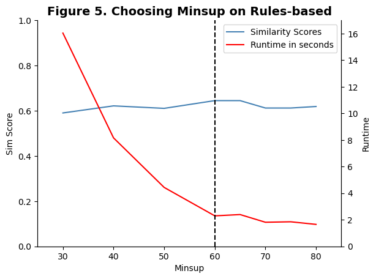

```python
minsup_compare = pd.read_excel("results_minsup.xlsx")

# Plotting
fig, ax1 = plt.subplots()

# Simscore plot
ax1.set_xlabel('Minsup')
ax1.set_ylabel('Sim Score', color='black')
sns.lineplot(data=minsup_compare, x='Minimum Support', y='Similarity Score', ax=ax1, color='steelblue', label="Similarity Scores")
ax1.tick_params(axis='y', labelcolor='black')
ax1.set_ylim(0, 1)

# Creating second y-axis
ax2 = ax1.twinx()
ax2.set_ylabel('Runtime', color='black')
sns.lineplot(data=minsup_compare, x='Minimum Support', y='Runtime (s)', ax=ax2, color='red', label="Runtime in seconds")
ax2.tick_params(axis='y', labelcolor='black')
ax2.set_ylim(0, 17)

# Draw vertical dotted line at x=60
plt.axvline(x=60, color='black', linestyle='--')

# Adding legends
lines, labels = ax1.get_legend_handles_labels()
lines2, labels2 = ax2.get_legend_handles_labels()
ax1.get_legend().remove()
ax2.get_legend().remove()
ax2.legend(lines + lines2, labels + labels2, loc='upper right')

# Setting x-axis limits
ax1.set_xlim(25, 85)

# Other elements
plt.title("Figure 5. Choosing Minsup on Rules-based", fontsize=14, weight='bold')
sns.despine(top=True, right=False)

# Show plot
plt.show()
```

We have selected a minimum support value of 60 for our association rule mining process. This choice is based on the evaluation of similarity scores across various minimum support thresholds. By setting the minimum support at 60, we aim to strike a balance between computational efficiency and recommendation accuracy, ensuring that the generated association rules are sufficiently robust to provide meaningful recommendations to users.

```python
rules = find_rules_unary(
    clean_user_profiles_df, clean_item_profiles_df, sample_user,
    minsup=60, minconf=60
)
recommended_rules = recommend_rules(clean_user_profiles_df,
                              clean_item_profiles_df,
                              rules, sample_user,
                              n_recommendations)

print("Recommended Games using Rules Based:")
recommended_rules
```

```
Recommended Games using Rules Based:
```

```
[620, 10680, 21690, 23530, 25700]
```

```python
item_profiles_df['Name'][recommended_rules]
```

```
appid
620                                    Portal 2
10680                      Aliens vs. Predator™
21690                           Resident Evil 5
23530    Earth Defense Force: Insect Armageddon
25700                 Madballs in Babo:Invasion
Name: Name, dtype: object
```

```python
recommended_profiles = clean_item_profiles_df.loc[recommended_rules][:n_recommendations]
rated_profiles = clean_item_profiles_df.loc[user_liked][:n_recommendations]

similarity_score = calculate_cosine_similarity(rated_profiles, recommended_profiles)
print("Similarity score (Cosine):", similarity_score)
```

```
Similarity score (Cosine): 0.6446912117051616
```

#### **VALIDATION**

##### **Monte Carlo Validation**

After all iterations, the mean similarity score for each iteration is calculated, and these mean scores are stored in the mean_scores list.

```python
##############
# Validation #
##############

# Monte-Carlo Simulation
# n_tests = 30
# n_users = 100
# n_recommendations = 5
# mean_scores = []


# for _ in range(n_tests):
#     np.random.seed(_)
#     random_user_ids = np.random.choice(clean_user_profiles_df.index, n_users, replace=False)

#     similarity_scores = []
#     for user_id in random_user_ids:
#         user_liked = clean_user_profiles_df.loc[user_id].dropna().index
#         rules = find_rules_unary(
#             clean_user_profiles_df, clean_item_profiles_df, user_id,
#             minsup=60, minconf=60
#         )
#         recommended = recommend_rules(
#             clean_user_profiles_df, clean_item_profiles_df, rules, user_id,
#             n_recommendations
#         )

#         recommended_profiles = clean_item_profiles_df.loc[recommended][:n_recommendations]
#         rated_profiles = clean_item_profiles_df.loc[user_liked][:n_recommendations]

#         similarity_score = calculate_cosine_similarity(rated_profiles, recommended_profiles)
#         similarity_scores.append(similarity_score)

#     mean_similarity_score = np.mean(similarity_scores)
#     mean_scores.append(mean_similarity_score)

# print("Mean Similarity Scores for 10 iterations:", mean_scores)
# print(np.mean(mean_scores))
```

##### **Baseline Validation**

Aside from the validation using monte carlos simulation, a live testing was also conducted to validate the similarities using organic inputs and comparing its similarity to real-world baselines.

```python
# Test new user

# Define the columns to set to 1
columns_to_set_1 = [292030, 22380, 72850, 17450, 1328670]
new_sample_id = 0

# Add a new row with index 0 and set specified columns to 1
clean_user_profiles_df.loc[new_sample_id] = None  # Initialize all values to 0
clean_user_profiles_df.loc[new_sample_id, columns_to_set_1] = 1
```

```python
print("User's chosen games:")
item_profiles_df['Name'][columns_to_set_1]
```

```
User's chosen games:
```

```
appid
292030          The Witcher® 3: Wild Hunt
22380                  Fallout: New Vegas
72850         The Elder Scrolls V: Skyrim
17450                 Dragon Age: Origins
1328670    Mass Effect™ Legendary Edition
Name: Name, dtype: object
```

```python
# Recalculate profiles because of added column
clean_item_profiles_df = item_profiles_df.copy()
clean_item_profiles_df.drop(columns='Name', inplace=True)

clean_item_profiles_df.head()

# Filter out only common columns
common_app_columns = clean_user_profiles_df.columns.intersection(
    clean_item_profiles_df.index)
clean_user_profiles_df = clean_user_profiles_df[common_app_columns]
clean_item_profiles_df = (clean_item_profiles_df
                          [clean_item_profiles_df.index.isin
                           (clean_user_profiles_df.columns.tolist())])
```

**Unary model**

Going to the first model, the recommendations of a unary aggregation recommender system is only 68% similar to the input games:

```python
# Unary Agg
user_profile_agg_unary = compute_user_profile_agg_unary(
    clean_user_profiles_df, clean_item_profiles_df, 0
)

recommended_unary = recommend_agg_unary(clean_user_profiles_df,
                                  clean_item_profiles_df,
                                  user_profile_agg_unary,
                                  new_sample_id,
                                  n_recommendations)
recommended_unary
```

```
[341730, 551770, 307940, 420850, 603100]
```

```python
item_profiles_df['Name'][recommended_unary]
```

```
appid
341730    Dustoff Heli Rescue
551770                   ECHO
307940       Radiation Island
420850            Cosmic Leap
603100                ATOMINE
Name: Name, dtype: object
```

```python
unary_profiles = clean_item_profiles_df.loc[recommended_unary][:n_recommendations]
rated_profiles = clean_item_profiles_df.loc[columns_to_set_1][:n_recommendations]

similarity_score = calculate_cosine_similarity(rated_profiles, unary_profiles)
print("Similarity score (Cosine):", similarity_score)
```

```
Similarity score (Cosine): 0.6839947757942465
```

**Rules-based model Baseline**

Finally, using the rules-based model produced the best results at 74% beating the other external baselines and the previous model significantly

```python
# Rules Based
rules = find_rules_unary(
    clean_user_profiles_df, clean_item_profiles_df, new_sample_id,
    minsup=60, minconf=60
)
recommended_rules_based = recommend_rules(clean_user_profiles_df,
                              clean_item_profiles_df,
                              rules, new_sample_id,
                              n_recommendations)
recommended_rules_based
```

```
[20920, 33100, 40390, 42910, 49520]
```

```python
item_profiles_df['Name'][recommended_rules_based]
```

```
appid
20920    The Witcher 2: Assassins of Kings Enhanced Edi...
33100                                        Alien Shooter
40390                                 Risen 2: Dark Waters
42910                                              Magicka
49520                                        Borderlands 2
Name: Name, dtype: object
```

```python
rules_profiles = clean_item_profiles_df.loc[recommended_rules_based][:n_recommendations]
rated_profiles = clean_item_profiles_df.loc[columns_to_set_1][:n_recommendations]

similarity_score = calculate_cosine_similarity(rated_profiles, rules_profiles)
print("Similarity score (Cosine):", similarity_score)
```

```
Similarity score (Cosine): 0.7423441579372805
```

**Globally-Popular Baseline**

Using globally trending games as a baseline, the similarity of this set to the input set is only around 45%. this may be attributed to the fact that the globally trending set is an aggregate of the global popularity of particular games in terms of its accessibility, initial hype, and mass appeal. These factors may somehow diminish the contributions of game features to the overall acceptance of any specific games

```python
global_popular = [570, 578080, 440, 730]
item_profiles_df['Name'][global_popular]
```

```
appid
570                                 Dota 2
578080                 PUBG: BATTLEGROUNDS
440                        Team Fortress 2
730       Counter-Strike: Global Offensive
Name: Name, dtype: object
```

```python
# Define the columns to set to 1
new_sample_id = 1

# Add a new row with index 0 and set specified columns to 1
clean_user_profiles_df.loc[new_sample_id] = None
clean_user_profiles_df.loc[new_sample_id, global_popular] = 1

# Recalculate beccause of added column
clean_item_profiles_df = item_profiles_df.copy()
clean_item_profiles_df.drop(columns='Name', inplace=True)

clean_item_profiles_df.head()

# Filter out only common columns
common_app_columns = clean_user_profiles_df.columns.intersection(
    clean_item_profiles_df.index)
clean_user_profiles_df = clean_user_profiles_df[common_app_columns]
clean_item_profiles_df = (clean_item_profiles_df
                          [clean_item_profiles_df.index.isin
                           (clean_user_profiles_df.columns.tolist())])

global_profiles = clean_item_profiles_df.loc[global_popular][:n_recommendations]
rated_profiles = clean_item_profiles_df.loc[columns_to_set_1][:n_recommendations]

similarity_score = calculate_cosine_similarity(rated_profiles, global_profiles)
print("Similarity score (Cosine):", similarity_score)
```

```
Similarity score (Cosine): 0.45456280361509177
```

**Steam-generic Baseline**

Another external baseline used is the generic recommendations from steam. This was taken from the steam homepage under the segment "Featured". This is equated to the initial offering of steam to a cold-started user profiles. The similarity score with this is a bit higher than the global recommendation at 53%.

```python
#Steam Generic
steam_generic = [1085660, 1129580, 594650, 916440]
item_profiles_df['Name'][steam_generic]
```

```
appid
1085660           Destiny 2
1129580    Medieval Dynasty
594650       Hunt: Showdown
916440            Anno 1800
Name: Name, dtype: object
```

```python
# Define the columns to set to 1
new_sample_id = 1

# Add a new row with index 0 and set specified columns to 1
clean_user_profiles_df.loc[new_sample_id] = None
clean_user_profiles_df.loc[new_sample_id, steam_generic] = 1

# Recalculate beccause of added column
clean_item_profiles_df = item_profiles_df.copy()
clean_item_profiles_df.drop(columns='Name', inplace=True)

clean_item_profiles_df.head()

# Filter out only common columns
common_app_columns = clean_user_profiles_df.columns.intersection(
    clean_item_profiles_df.index)
clean_user_profiles_df = clean_user_profiles_df[common_app_columns]
clean_item_profiles_df = (clean_item_profiles_df
                          [clean_item_profiles_df.index.isin
                           (clean_user_profiles_df.columns.tolist())])

steam_gen_profiles = clean_item_profiles_df.loc[steam_generic][:n_recommendations]
rated_profiles = clean_item_profiles_df.loc[columns_to_set_1][:n_recommendations]

similarity_score = calculate_cosine_similarity(rated_profiles, steam_gen_profiles)
print("Similarity score (Cosine):", similarity_score)
```

```
Similarity score (Cosine): 0.5388436397180506
```

**Steam User-specific Baseline**

Using the own steam profile of the test user (which contains the initial seed games), we also measured the similarity of those to the specific recommendation of steam (based on games played). This netted to a total of 65% similarity. This can be attributed to several factors like, other games included in the user's library, the consideration of steam with other users' preferences, as well as influence of recently released / trending games.

```python
# Steam user specific
steam_specific = [1017900, 610370, 1151640, 1085660, 1091500]
item_profiles_df['Name'][steam_specific]
```

```
appid
1017900     Age of Empires: Definitive Edition
610370                          Desperados III
1151640    Horizon Zero Dawn™ Complete Edition
1085660                              Destiny 2
1091500                         Cyberpunk 2077
Name: Name, dtype: object
```

```python
# Define the columns to set to 1
new_sample_id = 1

# Add a new row with index 0 and set specified columns to 1
clean_user_profiles_df.loc[new_sample_id] = None
clean_user_profiles_df.loc[new_sample_id, steam_specific] = 1

# Recalculate beccause of added column
clean_item_profiles_df = item_profiles_df.copy()
clean_item_profiles_df.drop(columns='Name', inplace=True)

clean_item_profiles_df.head()

# Filter out only common columns
common_app_columns = clean_user_profiles_df.columns.intersection(
    clean_item_profiles_df.index)
clean_user_profiles_df = clean_user_profiles_df[common_app_columns]
clean_item_profiles_df = (clean_item_profiles_df
                          [clean_item_profiles_df.index.isin
                           (clean_user_profiles_df.columns.tolist())])

steam_spec_profiles = clean_item_profiles_df.loc[steam_specific][:n_recommendations]
rated_profiles = clean_item_profiles_df.loc[columns_to_set_1][:n_recommendations]

similarity_score = calculate_cosine_similarity(rated_profiles, steam_spec_profiles)
print("Similarity score (Cosine):", similarity_score)
```

```
Similarity score (Cosine): 0.6548443141048286
```

## **SUMMARY AND INSIGHTS**

- Our recommender prioritizes game content similarities over popularity or trends, assisting game discovery tailored to preferences in terms of content.
- This approach is beneficial for streamers who prioritize tailored content creation, offering a better fit for their needs.
- Since popularity isn't a primary factor, it also offers indie games equal exposure opportunities for discovery within the streaming community, thus enhancing diversity.

## **RECOMMENDATION**

To improve the effectiveness and personalization of recommendation systems for projects, such as those involving game recommendations, a strategic approach focusing on both personalization and performance is necessary. Below is a recommended plan based on the outlined objectives:

**Improving Personalization of Recommenders** Personalization is key to engaging users by providing recommendations that closely match their interests and preferences. Here's how to improve it:

- **Weighted Feature Engineering:** Incorporates weighted features, prioritizing elements that significantly impact user preferences. This could involve:
- **Genre and Category Analysis:** Assign higher weights to genres or categories that users show a consistent preference for.
- **Date Range Checks and Release Dates:** Incorporate features that consider how recent a game is and whether it falls within a user's preferred date range, adjusting the weight based on these factors.
- **Popularity Filters:** Implement filters based on game's popularity.

**Improving Performance of Recommenders** Enhancing the performance of recommendation systems involves optimizing their efficiency, accuracy, and scalability. Here are the ways to achieve this:

- Apply data reduction techniques on Game Profiles.
- Apply clustering on game profiles
- Extending the data by aggregating to other datasets for game profiles like Twitch and data from other platforms such as GoG and Epic.

## **SOURCES**

1. Fronkon Games. (n.d.). Steam Games Dataset. Kaggle. Retrieved from https://www.kaggle.com/datasets/fronkongames/steam-games-dataset/data
2. Andrew Mvd. (n.d.). Steam Reviews Dataset. Kaggle. Retrieved from https://www.kaggle.com/datasets/andrewmvd/steam-reviews
3. Statista. (n.d.). Video Games - Worldwide | Statista Market Forecast. Statista. Retrieved from https://www.statista.com/outlook/dmo/digital-media/video-games/worldwide
4. Game. (n.d.). The Most Important Criteria Influencing Computer and Video Game Purchases. Retrieved from https://www.game.de/en/the-most-important-criteria-influencing-computer-and-video-game-purchases/
5. Statista. (n.d.). Number of games released on Steam as of October 2020, by developer type | Statista. Retrieved from https://www.statista.com/statistics/1411839/number-games-released-steam-developer-type/